# PG2 Informe

# Título: Recopilación de datos de actividades académicas, transporte y vivienda en estudiantes de UTEC después del regreso a la presencialidad

# Introducción

### Relevancia

#### Importancia

La importancia del tema propuesto radica en la posibilidad de ser usado como una herramienta para el conocimiento de la situación actual de los estudiantes de UTEC, con el fin de brindar datos socioeconómicos y los cuales reflejan la realidad de un sector de estudiantes, puede ser un buen punto de partida para empezar a recolectar datos de todos los alumnos activos de la universidad. Ya que con estas herramientas la universidad y las áreas responsables podrían brindar o facilitar ciertos beneficios a los estudiantes, lo cual se vería reflejado en su desarrollo.

#### Preguntas Generales

¿Cuáles son los patrones de mayor interés? ¿Cuáles son los cambios más notorios que se perciben al retomar la presencialidad? ¿El lugar en donde viven los estudiantes afecta su desempeño? ¿El tipo de transporte que usan los estudiantes tiene consecuencias sobre el nivel de estrés que presenta?

#### Preguntas Específicas

¿Cual es la edad con mayor numero de becas? ¿Cuales son las edades en las que menor presencia de trabajo se observa? ¿Que porcentaje de alumnos cuenta con beca? ¿Cual es el principal método de movilización de estudiantes? ¿Como perciben los alumnos la calidad de enseñanza ?

### Planificación

En el apartado de planeación nuestro grupo tuvo en cuenta los plazos expuestos en el Diagrama de Gantt. Lo mencionado anteriormente es de mucha ayuda para organizarnos y ponernos de acuerdo con el objetivo de agendar reuniones de Zoom donde coordinamos lo que íbamos a hacer para las entregas y como nos dividimos el trabajo.

P0 Informe: El primer informe entregado en el curso en donde planteábamos tres temas al profesor para nuestro proyecto.

P1 Recolección de datos: Periodo en donde realizamos encuestas en al universidad para crear nuestra base de datos

P1 Compilación y Ensayos Exposición: Realizamos la limpieza de base de datos y Creamos el archivo del informe y la exposición para posteriormente ensayarla.(Semana 6)

Feedback: Reunión con la profesora para recibir un feedback sobre la PG1.(Semana 11)

Corrección PG1: Tomando en cuenta que dentro de la rúbrica de la PG2 se evalúa aspectos a mejorar que la profesora mencionó en el feedback decidimos repartirnos este proceso entre los miembros del grupo durante la semana 12.(Semana 12)

Reconocimiento de modelos: Reconocimos los modelos dentro de nuestro proyecto.(Semana 13)

Recopilación de de información y ensayos: En función del reconocimiento de modelos rellenamos el informe de la PG2 y creamos la exposición. (Semana 13 a 14)

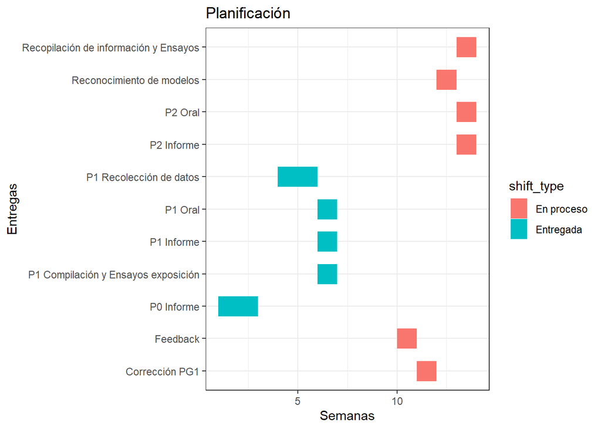

# Datos

### Recolección de datos

Para la recolección de datos primero realizamos una planeación sobre la disponibilidad del grupo para realizar entrevistas en el campus de la Universidad de Ingeniería y Tecnología. El equipo decidió utilizar un forms de Google y una encuesta creada en la plataforma llamada forms.app para que los estudiantes entrevistados, principalmente en los pisos seis y dos, rellenen. Se eligió priorizar las encuestas en estos pisos debido a que existían más estudiantes con tiempo libre en estos. Cabe recalcar que la elección del forms fue debido a la accesibilidad, pues les mostraríamos un QR para escanear y entrar a completar la encuesta. Asimismo, para incentivar las participaciones se planeó hacer un sorteo de dos tarjetas de regalo de Steam y en adición se les informo que al completar la encuesta se le daría golosinas. Esto fue de gran utilidad al ayudarnos a obtener más participación por parte de los estudiantes.

Link forms.app: [Click aquí](https://my.forms.app/form/63247a0af576d119e24ea7dd) Link Google Forms: [Click aquí](https://docs.google.com/forms/d/e/1FAIpQLSe5oM4RO3HoTycMetSCKoXtNTjX_CnWopEpbJNSB9FsP2UsCg/viewform?usp=sf_link)

### Población, muestra y muestreo

La población de estudio a la cual hemos podido recurrir sería los estudiantes de UTEC, los cuales obviamente los encontraremos en la Casa de Estudios antes mencionada, la cantidad de estudiantes que necesitaremos para nuestro proyecto esta establecido para 200 estudiantes a más; consideramos apropiada esta cantidad ya que podemos reducir las probabilidades que se dispersen las respuestas; para terminar el tipo de muestreo que se encontraría en nuestro proyecto sería el Probabilístico para ser mas especifico seria el Muestreo aleatorio simple (MAS) esto debido a que en este proyecto buscamos gente al azar, no esta definida desde un principio, y viendo que todos nuestra población tienen la misma probabilidad de llevarse un premio al participar de este proyecto.

### Variables

- Edad (Edad):Variable Numérica Discreta pero con restricción que sea número entero.
- Ingresos mensuales (Ingresos):Variable Numérica Discreta pero con restricción que sea número entero.
- Costo de Alquiler (CtoAlquiler):Variable Numérica Discreta pero con restricción que sea número entero.
- Número de Personas conviviendo (NroPersonas):Variable Numérica Discreta pero con restricción que sea número entero.
- Costo de Transporte Público diario (CtoTransporte):Variable Numérica Continua tiene que ser numero no necesariamente entero.
- Cantidad de Vehículos que usa para llegar a la universidad (CtdadVehiculos): Numérica discreta con restricción de que sea número entero
- Cantidad de Cursos matriculados (CtdadCursos):Variable Numérica Discreta pero con restricción que sea número entero.
- Horas de Viaje diarias (HrasViaje):Variable Numérica Continua pero con restricción que sea número entero tiene que ser numero no necesariamente entero.
- Horas de Clase semanales (HrasClase):Variable Numérica Discreta pero con restricción que sea número entero.
- Horas de Estudio semanales (HrasEstudio):Variable Numérica Continua tiene que ser numero no necesariamente entero.
- Nombre (Nombre): Variable Categorica Nominal con restriccion de ser palabras.
- Código (Código): Variable Categórica Nominal con restriccion de ser numeros.
- Distrito (Distrito): Variable Categorica Nominal y con restriccion de solo poder elegir una opcion.
- Beca (Beca): Variable Categorica Nominal con restriccion de solo poder elegir una opcion.
- Trabajo (Trabajo): Variable Categorica Nominal con restriccion de solo poder elegir una opcion.
- Alquiler (Alquiler): Variable Categorica Nominal con restriccion de solo poder elegir una opcion.
- Tipo de Transporte (TipoTransporte): Variable Categorica Ordinal con restriccion de solo poder elegir una opcion.
- Comodidad a la hora de viajar (Comodidad): Variable Categorica Ordinal con restriccion de solo poder elegir una opcion.
- Calidad de enseñanza (Calidad): Variable Categorica Ordinal con restriccion de solo poder elegir una opcion.
- Estres (Estres): Variable Categorica Ordinal con restriccion de solo poder elegir una opcion.

### LImpieza de base de datos

Comenzamos leyendo la base de datos del proyecto usando la librería readr y su función read_csv. Posteriormente para no tomar en cuenta las variables no relevantes como la marca temporal generada por Google Forms y My forms reasignamos nuestra variable asignada a la base datos como la misma pero ahora solo contando las columnas que excluyan a las variables irrelevantes.

Después del paso anterior pasamos al apartado de la limpieza en sí. Al limpiar cada variable aplicamos table con el objetivo de ver la diversidad de los datos para corregirlos. Después de esto corregimos aquellos datos que se podían corregir. Por otro lado, para aquellos datos que no se entendían o no tenían nada que ver con las preguntas los reemplazamos por NA. Asimismo, nos aseguramos de que R reconozca todas las variables numéricas como num y las categóricas como chr, esto con el objetivo de que no hayan problemas a la hora de usar descriptores gráficos o numéricos. Cabe recalcar que este cambio de tipo de variable en R lo hicimos después de asegurarnos que en cada variable hayan solo datos del mismo. Finalmente, nos encargamos de reemplazar por NA los datos irreales de cada una de las variables.

Del mismo modo, es prudente mencionar que el apartado de la limpieza no fue en extrema dificultad pues a la hora de nosotros crear el forms lo hicimos justo pensando en la limpieza. Es por esta razón que al aplicar table nos percatamos que no todas las variables requieren limpieza.

En resumen, primero no tomamos en cuenta las variables no relevantes, luego reemplazamos o modificamos los datos de las variables con el objetivo de asegurarnos de que solo hayan datos de un solo tipo para cambiar en R aquellos datos que no deben ser de tipo num o chr. Para concluir con esta limpieza también reemplazamos por NA aquellos datos irreales de cada una de las variables. Habiendo dicho esto, nosotros consideramos que la base de datos está limpia pues nos hemos asegurado de que no hayan datos corruptos o irreales que influyan negativamente en el análisis descriptivo.

Primero importamos la libreria para leer el csv de la base de datos.

```r
DF <- read_csv("BDD.csv")
```

Borramos Las columnas inservibles.

```r
DF <- DF[,3:ncol(DF)]
```

Cambiamos de nombre a las variables para que sea más fácil llamarlas.

```r
DF %>% rename(Nombre = `Apellidos y Nombres`, Codigo = `Código de alumno`, Edad = `Edad.  INGRESA SOLO VALORES NUMÉRICOS`, Distrito = `¿En qué distrito vives?`, Beca = `¿Eres becado?`, Trabajo = `¿Trabajas?`, Ingresos = `Ingresos mensuales en NÚMERO ENTERO (Propinas + sueldo si trabajas).   INGRESA SOLO VALORES NUMÉRICOS`, Alquiler = `¿Alquilas algún inmueble en donde residir?`, CtoAlquiler = `Costo de alquiler en soles y NÚMERO ENTERO (solo en caso de que alquiles). Si no alquilas deja la respuesta a esta pregunta en blanco.   INGRESA SOLO VALORES NUMÉRICOS`, NroPersonas = `¿Cuántas personas viven contigo? en NÚMEROS ENTEROS.  INGRESA SOLO VALORES NUMÉRICOS`, TipoTransporte = `¿Qué tipo de transporte usas para ir y venir de la Universidad?`, CtoTransporte = `Costo total de transporte público diario en soles (se puede ingresar con decimales). Si no usas transporte público deja esta pregunta en blanco.  INGRESA SOLO VALORES NUMÉRICOS`, CtdadVehiculos = `¿Cuántos vehículos de transporte público usas para ir a la universidad? Elige 0 si no usas transporte público.`, HrsViaje = `Horas de viaje totales diarias (puedes colocar tu respuesta en números decimales). INGRESA SOLO VALORES NUMÉRICOS`, Comodidad = `¿Del 1 al 5 qué tan cómodo te sientes al transportarte?`, CtdadCursos = `¿En cuántos cursos te has matriculado este ciclo?`, HrasClase = `¿Cuántas horas de clase semanales tienes? Ingresa tu respuesta en números enteros.   INGRESA SOLO VALORES NUMÉRICOS`, HrasEstudio = `¿Cuántas horas en total te dedicas a estudiar por semana? (puedes colocar tu respuesta en números decimales).   INGRESA SOLO VALORES NUMÉRICOS`, Calidad = `Califica la calidad de enseñanza en la presencialidad del 1 al 5`, Estres = `Califica tu nivel de estrés del 1 al 5`) -> DF
```

Hacemos un table a la variable para ver y modificar o reemplazar por NA a aquellos datos corruptos

```r
table(DF$Edad)
```

```
##
##      17      18      19      20      21      22      23      24 24 años      25
##      25      55      41      36      25      14       3       3       1       2
##      26      27
##       1       2
```

```r
DF$Edad[DF$Edad == "24 años"] <- 24
table(DF$Edad)
```

```
##
## 17 18 19 20 21 22 23 24 25 26 27
## 25 55 41 36 25 14  3  4  2  1  2
```

Al hacer table en el apartado de distrito nos damos cuenta que no hay datos corruptos, esto debido a que esta pregunta en la encuesta fue de carácter obligatorio y de opción múltiple.

```r
table(DF$Distrito)
```

```
##
##                   Ancón             Ate Vitarte                Barranco
##                       1                       9                      29
##                   Breña                  Callao              Carabayllo
##                       2                       3                       2
##              Chaclacayo              Chorrillos             Cieneguilla
##                       5                      16                       1
##                   Comas             El Agustino           Independencia
##                       4                       1                       2
##             Jesús María               La Molina             La Victoria
##                       2                       7                       1
##                    Lima                   Lince              Los Olivos
##                      12                       2                       5
##              Lurigancho       Magdalena del Mar              Miraflores
##                       2                       3                       5
##              Pachacamac            Pueblo libre           Puente piedra
##                       1                       4                       1
##                   Rímac               San borja              San Isidro
##                       2                       5                       5
##  San Juan de Lurigancho  San Juan de Miraflores    San Martín de Porres
##                       8                       9                       9
##              San Miguel             Santa Anita       Santiago de Surco
##                       4                       1                      29
##               Surquillo       Villa El Salvador Villa María del triunfo
##                       8                       3                       5
```

Analizamos la variable beca y no hay problema con ella tampoco.

```r
table(DF$Beca)
```

```
##
##  No  Si
## 131  77
```

No hay problema

```r
table(DF$Trabajo)
```

```
##
##  No  Si
## 177  31
```

En ingresos encontramos respuestas que deben ser reemplazadas así que procedimos a ello.

```r
table(DF$Ingresos)#Limpiar
```

```
##
##                 0                00                10               100
##                29                 1                 1                11
##              1000           1025.00              1100              1125
##                13                 1                 2                 1
##              1150               120              1200              1250
##                 1                 2                13                 1
##              1260              1290              1300               150
##                 4                 1                 4                 2
##              1500               160              1600               170
##                 4                 2                 3                 2
##              1750              1880                20               200
##                 2                 1                 5                12
##              2000              2300               240               250
##                 1                 1                 1                 3
```

[output cut: 16 more lines]

```r
DF$Ingresos[DF$Ingresos == "00"] <- "0"
DF$Ingresos[DF$Ingresos == "No tengo ingresos"] <- "0"
table(DF$Ingresos)
```

```
##
##       0      10     100    1000 1025.00    1100    1125    1150     120    1200
##      31       1      11      13       1       2       1       1       2      13
##    1250    1260    1290    1300     150    1500     160    1600     170    1750
##       1       4       1       4       2       4       2       3       2       2
##    1880      20     200    2000    2300     240     250    2500      30     300
##       1       5      12       1       1       1       3       3       2       7
##    3000     320    3200     330      40     400    4000     450     480      50
##       2       2       1       1       2      13       1       2       1       4
##     500      60     600    6000     620     650     700     750      80     800
##       9       1       6       1       1       1       1       1       2       1
##      90     900     915     920     930     950     980
##       1       1       1      10       2       1       1
```

No hay problema.

```r
table(DF$Alquiler)
```

```
##
##  No  Si
## 155  53
```

En esta variable reemplazamos por NA y modificamos aquellas variables que lo necesitaban.

```r
table(DF$CtoAlquiler)
```

```
##
##     ------          0        100       1000       1200       1300       1340
##          1         22          1          1          1          1          1
##       1500       1550       2000       2400        270        300       3000
##          1          1          1          2          1          2          1
##       3200        350        400        450        500        510        550
##          2          1          7          4          6          1          2
##        600        650        720        750        780        800        850
##          9          2          1          3          1          2          1
##        950 No alquilo
##          1          1
```

```r
sum(is.na(DF$CtoAlquiler))
```

```
## [1] 127
```

```r
class(DF$CtoAlquiler)
```

```
## [1] "character"
```

```r
DF$CtoAlquiler[DF$CtoAlquiler == "------"] <- 0
DF$CtoAlquiler[DF$CtoAlquiler == "0"] <- 0
DF$CtoAlquiler[DF$CtoAlquiler == "No alquilo"] <- 0
DF$CtoAlquiler[is.na(DF$CtoAlquiler)] <- 0
table(DF$CtoAlquiler)
```

```
##
##    0  100 1000 1200 1300 1340 1500 1550 2000 2400  270  300 3000 3200  350  400
##  151    1    1    1    1    1    1    1    1    2    1    2    1    2    1    7
##  450  500  510  550  600  650  720  750  780  800  850  950
##    4    6    1    2    9    2    1    3    1    2    1    1
```

No hay problema

```r
table(DF$CtoAlquiler)
```

```
##
##    0  100 1000 1200 1300 1340 1500 1550 2000 2400  270  300 3000 3200  350  400
##  151    1    1    1    1    1    1    1    1    2    1    2    1    2    1    7
##  450  500  510  550  600  650  720  750  780  800  850  950
##    4    6    1    2    9    2    1    3    1    2    1    1
```

En la variable número de personas si nos percatamos de que no hay solo valores numericos así que modificamos ese valor porque si se podía corregir.

```r
table(DF$NroPersonas)
```

```
##
##    0    1   12    2    3    4    5    6    7    8    9 Sola
##   25   24    1   30   43   42   26    8    4    3    1    1
```

```r
DF$NroPersonas[DF$NroPersonas=="Sola"]<-0
table(DF$NroPersonas)
```

```
##
##  0  1 12  2  3  4  5  6  7  8  9
## 26 24  1 30 43 42 26  8  4  3  1
```

No hay problema

```r
table(DF$TipoTransporte)
```

```
##
##             Camino  Movilidad Privada Transporte Público    Vehículo propio
##                 32                 15                132                 29
```

En la variable CtoTransporte si notamos problemas así que los corregimos y reemplazamos por NA.

```r
table(DF$CtoTransporte)
```

```
##
##       .       0      0.     0.5       1     1.5     1.8    1.80      10   10.20
##       1      16       1       1       2       2       1       1      12       1
##   10.40      11   11.40      12      13     144      15     150      18     189
##       1       2       1       1       1       1       6       1       1       1
##       2     2.5    2.50      20   21.25      23      25       3     3,6     3.5
##       8       3       2       4       1       1       4      12       1       3
##      32       4    4.50      40       5 5 soles    5.00     5.5      50       6
##       1      10       3       1      14       1       1       2       1       8
##     6.5      60       7    7.50       8       9    9.50    9.60    S/10
##       1       2       7       1       5       2       1       1       1
```

```r
DF$CtoTransporte[DF$CtoTransporte=="."]<-0
DF$CtoTransporte[DF$CtoTransporte=="0."]<-0
DF$CtoTransporte[DF$CtoTransporte=="1.8"]<-"1.80"
DF$CtoTransporte[DF$CtoTransporte=="2.5"]<-"2.50"
DF$CtoTransporte[DF$CtoTransporte=="3,6"]<-3.60
DF$CtoTransporte[DF$CtoTransporte=="5 soles"]<-5
DF$CtoTransporte[DF$CtoTransporte=="5.00"]<-5
DF$CtoTransporte[DF$CtoTransporte=="S/10"]<-10
table(DF$CtoTransporte)
```

```
##
##     0   0.5     1   1.5  1.80    10 10.20 10.40    11 11.40    12    13   144
##    18     1     2     2     2    13     1     1     2     1     1     1     1
##    15   150    18   189     2  2.50    20 21.25    23    25     3   3.5   3.6
##     6     1     1     1     8     5     4     1     1     4    12     3     1
##    32     4  4.50    40     5   5.5    50     6   6.5    60     7  7.50     8
##     1    10     3     1    16     2     1     8     1     2     7     1     5
##     9  9.50  9.60
##     2     1     1
```

```r
sum(is.na(DF$CtoTransporte))
```

```
## [1] 52
```

```r
DF$CtoTransporte[is.na(DF$CtoTransporte)] <- 0
```

No hay problema.

```r
table(DF$CtdadVehiculos)
```

```
##
##  0  1  2  3  4  6
## 56 47 64 27  1  1
```

```r
sum(is.na(DF$CtdadVehiculos))
```

```
## [1] 12
```

```r
DF$CtdadVehiculos[is.na(DF$CtdadVehiculos)] <- 0
```

En la variable HrsViaje también se observan datos que no deben de ir, por lo que seguimos procediendo con el reemplazo o corrección.

```r
table(DF$HrsViaje)
```

```
##
##          0        0,2        0,5        0.1       0.15       0.16       0.17
##         11          1          2          3          2          1          2
##        0.2       0.25        0.3       0.30        0.4        0.5        0.8
##          4          1          1          1          1          9          1
##          1        1,2        1,3       1.16        1.2       1.25        1.3
##         39          1          1          2          1          1          2
##       1.30       1.45        1.5       1.50        1.8        1/2       1:30
##          1          2          6          1          1          1          2
##         10     15 min          2    2 horas        2,3       2.40        2.5
##          1          1         42          2          1          1          5
##         20         25          3        3.5         30     30 min   30 minss
##          1          1         18          1          1          1          1
##      30min          4    4 horas         40     40 min          5       5min
##          1         17          1          2          1          3          1
##          6 80 minutos         90
##          2          1          1
```

```r
DF$HrsViaje[DF$HrsViaje == "1,2"] < 1.2
```

```
## [1] TRUE
```

```r
DF$HrsViaje[DF$HrsViaje == "3O min"] <-30
DF$HrsViaje[DF$HrsViaje == "80 minutos"] <-80
DF$HrsViaje[DF$HrsViaje == "0,2"] <-0.2
DF$HrsViaje[DF$HrsViaje == "1,3"] <-1.5
DF$HrsViaje[DF$HrsViaje == "0,2"] <-0.2
DF$HrsViaje[DF$HrsViaje == "1/2"] <-0.5
DF$HrsViaje[DF$HrsViaje == "2 horas"] <-2
DF$HrsViaje[DF$HrsViaje == "30 minss"] <-0.5
DF$HrsViaje[DF$HrsViaje == "30min"] <-0.5
DF$HrsViaje[DF$HrsViaje == "40 min"] <-0.8
DF$HrsViaje[DF$HrsViaje == "0,5"] <-0.5
DF$HrsViaje[DF$HrsViaje == "1:30"] <-1.5
DF$HrsViaje[DF$HrsViaje == "2,3"] <-2.5
DF$HrsViaje[DF$HrsViaje == "30 min"] <-0.5
DF$HrsViaje[DF$HrsViaje == "0,1"] <-0.1
DF$HrsViaje[DF$HrsViaje == "5min"] <-0.05
DF$HrsViaje[DF$HrsViaje == "15 min"] <-0.25
DF$HrsViaje[DF$HrsViaje == "4 horas"] <-4
table(DF$HrsViaje)
```

```
##
##    0 0.05  0.1 0.15 0.16 0.17  0.2 0.25  0.3 0.30  0.4  0.5  0.8    1  1,2 1.16
##   11    1    3    2    1    2    5    2    1    1    1   15    2   39    1    2
##  1.2 1.25  1.3 1.30 1.45  1.5 1.50  1.8   10    2 2.40  2.5   20   25    3  3.5
##    1    1    2    1    2    9    1    1    1   44    1    6    1    1   18    1
##   30    4   40    5    6   80   90
##    1   18    2    3    2    1    1
```

No hay problema.

```r
table(DF$Comodidad)
```

```
##
##  1  2  3  4  5
## 25 24 71 57 31
```

```r
table(DF$CtdadCursos)#Limpiar
```

```
##
##  1  2  3  4  5  6  7  8
##  1  2  8 18 59 87 32  1
```

```r
table(DF$HrasClase)
```

```
##
##                  0                 10                 11                 12
##                  1                  9                  1                  7
##                120                 13                 14                 15
##                  1                  2                  4                 12
##                 16           16 horas                 17                 18
##                  3                  1                  3                  7
##                 19                 20                 21                 22
##                  6                 23                  9                 13
## 22 horas semanales                 23                 24                 25
##                  1                 15                 15                 11
##                 26                 27                 28                 29
##                  7                 13                  3                  2
##                 30                 32                 33                 36
##                  9                  2                  1                  1
##                  4                 40           40 horas                 4h
##                  5                  1                  1                  1
##                  5                 55                  6                 6h
##                  5                  1                  4                  1
##                  7                  8                  9
##                  3                  3                  1
```

```r
DF$HrasClase[DF$HrasClase == "40 horas"] <- 40
DF$HrasClase[DF$HrasClase == "4h"] <- 4
DF$HrasClase[DF$HrasClase == "16 horas"] <- 16
DF$HrasClase[DF$HrasClase == "22 horas semanales"] <- 22
DF$HrasClase[DF$HrasClase == "6h"] <- 6
table(DF$HrasClase)
```

```
##
##   0  10  11  12 120  13  14  15  16  17  18  19  20  21  22  23  24  25  26  27
##   1   9   1   7   1   2   4  12   4   3   7   6  23   9  14  15  15  11   7  13
##  28  29  30  32  33  36   4  40   5  55   6   7   8   9
##   3   2   9   2   1   1   6   2   5   1   5   3   3   1
```

Se aprecian problemas en la variable HrasEstudio por lo que corregimos.

```r
table(DF$HrasEstudio)#Limpiar
```

```
##
##        1       10      100       12      12h       14       15 15 horas
##        5       35        1        9        1        6        4        1
##       16       18        2  2 horas     2.40       20       21       22
##        8        2        5        2        1       13        2        1
##       24       25       26       28        3       30       34       35
##        4        5        1        4        9        1        1        1
##        4       40       42       45        5        6        7       72
##       10        3        2        1       19       21       10        1
##        8       84        9       96
##       13        1        4        1
```

```r
DF$HrasEstudio[DF$HrasEstudio =="15 horas"] <-15
DF$HrasEstudio[DF$HrasEstudio =="2 horas"] <-2
DF$HrasEstudio[DF$HrasEstudio =="12h"] <-12
table(DF$HrasEstudio)
```

```
##
##    1   10  100   12   14   15   16   18    2 2.40   20   21   22   24   25   26
##    5   35    1   10    6    5    8    2    7    1   13    2    1    4    5    1
##   28    3   30   34   35    4   40   42   45    5    6    7   72    8   84    9
##    4    9    1    1    1   10    3    2    1   19   21   10    1   13    1    4
##   96
##    1
```

No hay problema.

```r
table(DF$Calidad)
```

```
##
##   1   2   3   4   5
##   2   4  29 108  65
```

No hay problema.

```r
table(DF$Estres)
```

```
##
##  1  2  3  4  5
##  6 15 48 61 78
```

#### Siguiente Paso(Convertir numéricas a categóricas y viceversa)

Después de limpiar los datos y asegurarnos que haya un solo tipo de datos en cada variable cambiamos los numéricos a categóricos.

```r
numCol<- c("Nombre", "Codigo", "Distrito", "Beca", "Trabajo", "Alquiler", "TipoTransporte", "Comodidad", "Calidad", "Estres")
factCol <- names(DF)[!names(DF)%in%numCol]
DF[factCol] <- lapply(DF[factCol], FUN = as.numeric)
numCol<- c("Nombre","Edad", "Ingresos", "CtoAlquiler", "CtoTransporte", "NroPersonas", "CtdadVehiculos", "HrsViaje", "CtdadCursos", "HrasClase", "HrasEstudio")
factCol <- names(DF)[!names(DF)%in%numCol]
DF[factCol] <- lapply(DF[factCol], FUN = as.character)

str(DF)
```

```
## tibble [208 x 20] (S3: tbl_df/tbl/data.frame)
##  $ Nombre        : chr [1:208] "Amy Lucero Fernández Briones" "Herrera Adriano Diego Alonso" "Beltran Abalos Sergio Edmundo" "Guerrero Castro Leticia Isabel" ...
##  $ Codigo        : chr [1:208] "202120744" "202110577" "202110507" "202110150" ...
##  $ Edad          : num [1:208] 18 20 19 18 18 19 20 18 19 20 ...
##  $ Distrito      : chr [1:208] "Santiago de Surco" "Los Olivos" "Pueblo libre" "La Molina" ...
##  $ Beca          : chr [1:208] "No" "No" "No" "No" ...
##  $ Trabajo       : chr [1:208] "No" "No" "No" "No" ...
##  $ Ingresos      : num [1:208] 600 320 20 200 50 1600 1300 500 0 300 ...
##  $ Alquiler      : chr [1:208] "No" "No" "No" "No" ...
##  $ CtoAlquiler   : num [1:208] 0 0 0 0 0 0 400 0 1300 0 ...
##  $ NroPersonas   : num [1:208] 3 5 5 4 4 4 1 5 2 4 ...
##  $ TipoTransporte: chr [1:208] "Transporte Público" "Transporte Público" "Transporte Público" "Vehículo propio" ...
##  $ CtoTransporte : num [1:208] 2 2.5 5 0 4.5 0 0 40 0 4.5 ...
##  $ CtdadVehiculos: num [1:208] 0 2 0 0 2 0 0 1 0 2 ...
##  $ HrsViaje      : num [1:208] 1 1.45 3 2 1 1 1 40 0 1.5 ...
##  $ Comodidad     : chr [1:208] "3" "2" "3" "4" ...
##  $ CtdadCursos   : num [1:208] 5 4 1 6 6 3 5 5 5 6 ...
##  $ HrasClase     : num [1:208] 17 15 4 25 23 10 12 14 23 6 ...
##  $ HrasEstudio   : num [1:208] 6 3 14 12 4 10 7 8 8 10 ...
##  $ Calidad       : chr [1:208] "5" "3" "4" "5" ...
##  $ Estres        : chr [1:208] "2" "2" "3" "4" ...
```

```r
table(DF$CtoTransporte)
```

```
##
##     0   0.5     1   1.5   1.8     2   2.5     3   3.5   3.6     4   4.5     5
##    70     1     2     2     2     8     5    12     3     1    10     3    16
##   5.5     6   6.5     7   7.5     8     9   9.5   9.6    10  10.2  10.4    11
##     2     8     1     7     1     5     2     1     1    13     1     1     2
##  11.4    12    13    15    18    20 21.25    23    25    32    40    50    60
##     1     1     1     6     1     4     1     1     4     1     1     1     2
##   144   150   189
##     1     1     1
```

```r
DF$CtoTransporte[DF$CtoTransporte > 100] <- NA
table(DF$CtoTransporte)
```

```
##
##     0   0.5     1   1.5   1.8     2   2.5     3   3.5   3.6     4   4.5     5
##    70     1     2     2     2     8     5    12     3     1    10     3    16
##   5.5     6   6.5     7   7.5     8     9   9.5   9.6    10  10.2  10.4    11
##     2     8     1     7     1     5     2     1     1    13     1     1     2
##  11.4    12    13    15    18    20 21.25    23    25    32    40    50    60
##     1     1     1     6     1     4     1     1     4     1     1     1     2
```

```r
table(DF$HrsViaje)
```

```
##
##    0 0.05  0.1 0.15 0.16 0.17  0.2 0.25  0.3  0.4  0.5  0.8    1 1.16  1.2 1.25
##   11    1    3    2    1    2    5    2    2    1   15    2   39    2    1    1
##  1.3 1.45  1.5  1.8    2  2.4  2.5    3  3.5    4    5    6   10   20   25   30
##    3    2   10    1   44    1    6   18    1   18    3    2    1    1    1    1
##   40   80   90
##    2    1    1
```

```r
DF$HrsViaje[DF$HrsViaje > 6] <- NA
DF$HrsViaje[DF$HrsViaje < 0.1] <- NA
table(DF$HrsViaje)
```

```
##
##  0.1 0.15 0.16 0.17  0.2 0.25  0.3  0.4  0.5  0.8    1 1.16  1.2 1.25  1.3 1.45
##    3    2    1    2    5    2    2    1   15    2   39    2    1    1    3    2
##  1.5  1.8    2  2.4  2.5    3  3.5    4    5    6
##   10    1   44    1    6   18    1   18    3    2
```

```r
table(DF$HrasClase)
```

```
##
##   0   4   5   6   7   8   9  10  11  12  13  14  15  16  17  18  19  20  21  22
##   1   6   5   5   3   3   1   9   1   7   2   4  12   4   3   7   6  23   9  14
##  23  24  25  26  27  28  29  30  32  33  36  40  55 120
##  15  15  11   7  13   3   2   9   2   1   1   2   1   1
```

```r
DF$HrasClase[DF$HrasClase > 40] <- NA
DF$HrasClase[DF$HrasClase < 4] <- NA
table(DF$HrasClase)
```

```
##
##  4  5  6  7  8  9 10 11 12 13 14 15 16 17 18 19 20 21 22 23 24 25 26 27 28 29
##  6  5  5  3  3  1  9  1  7  2  4 12  4  3  7  6 23  9 14 15 15 11  7 13  3  2
## 30 32 33 36 40
##  9  2  1  1  2
```

```r
table(DF$HrasEstudio)
```

```
##
##   1   2 2.4   3   4   5   6   7   8   9  10  12  14  15  16  18  20  21  22  24
##   5   7   1   9  10  19  21  10  13   4  35  10   6   5   8   2  13   2   1   4
##  25  26  28  30  34  35  40  42  45  72  84  96 100
##   5   1   4   1   1   1   3   2   1   1   1   1   1
```

```r
DF$HrasEstudio[DF$HrasEstudio > 45] <- NA
table(DF$HrasEstudio)
```

```
##
##   1   2 2.4   3   4   5   6   7   8   9  10  12  14  15  16  18  20  21  22  24
##   5   7   1   9  10  19  21  10  13   4  35  10   6   5   8   2  13   2   1   4
##  25  26  28  30  34  35  40  42  45
##   5   1   4   1   1   1   3   2   1
```

# Análisis Descriptivo

```
## Nuestra muestra cuenta con 208 observaciones de las cuales  177 están completas y  31 están incompletas. Asimismo, tiene  20 variables. Por otro lado tenemos  32  datos incompletos del total de  4160 .
```

### Clasificación de las variables

#### Variables Categóricas

1. Nombre **<- Nominal**
2. Codigo **<- Nominal**
3. Distrito **<- Nominal**
4. Beca **<- Nominal**
5. Trabajo **<- Nominal**
6. Alquiler **<- Nominal**
7. TipoTransporte **<- Nominal**
8. Comodidad **<- Ordinal**
9. Calidad **<- Ordinal**
10. Estres **<- Ordinal**

### Análisis de las variables

#### Variables Numéricas

##### **Edad**

Promedio: Lo que nos devuelve Rstudio en este apartado quiere decir que todos los datos dentro de la variable nombre están alrededor de 19.43269.

```r
mean(DF$Edad, na.rm = TRUE)
```

```
## [1] 19.43269
```

Cuantiles:

```r
quantile(DF$Edad, na.rm = TRUE)
```

```
##   0%  25%  50%  75% 100%
##   17   18   19   20   27
```

Dentro de este apartado de los cuantiles podemos encontrar dos descriptores numéricos más, al mínimo y al máximo. El **mínimo** sería el 0% pues recordando la difinición de cuantil y aplicándola en 0% podemos decir que al menos el 0% de los datos es menor o igual que el cuantil 0%, lo que nos daria como resultado el mínimo valor, 17. Bajo el mismo criterio analizaremos el cuantil 100% resultándonos el **máximo** valor, 27.

Moda: Es el valor que más se repite dentro de la variable Edad, en este caso no aplicamos ninguna función pues no existe ninguna que de la moda. Sin embargo, usando la definición de moda y el comando table podemos ver el valor que más se repite, el cual en este caso es el valor de 18.

```r
table(DF$Edad)
```

```
##
## 17 18 19 20 21 22 23 24 25 26 27
## 25 55 41 36 25 14  3  4  2  1  2
```

Rango: nos dará una idea de la dispersion de los datos de la variable Edad. En este caso el rango es de 10.

```r
max(DF$Edad) - min(DF$Edad)
```

```
## [1] 10
```

Varianza: La variabilidad es de 3.74424

```r
var(DF$Edad, na.rm = TRUE)
```

```
## [1] 3.74424
```

Desviación Estandar: La desviación estándar es

```r
sd(DF$Edad, na.rm = TRUE)
```

```
## [1] 1.935004
```

Gráfico de barras edad: Se aprecia gracias a este gráfico que más del 25% del total de encuestados tienen 18 años.

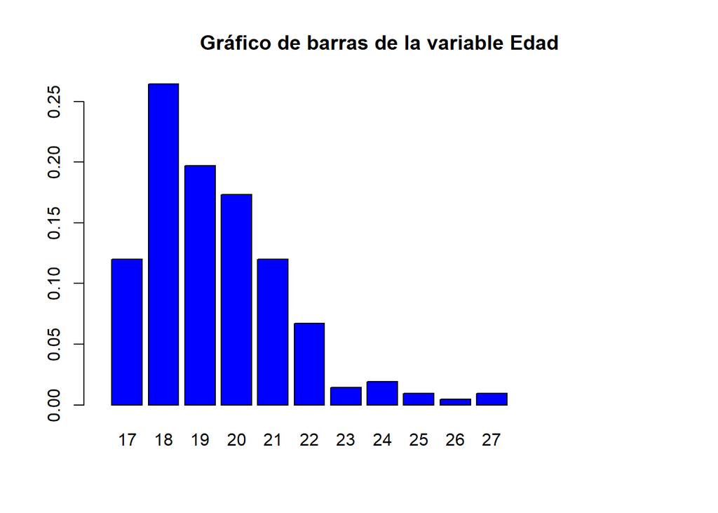

```r
barplot(prop.table(table(DF$Edad)),col=c("blue"),
      xlim=c(0,18), main = "Gráfico de barras de la variable Edad")
```

Gracias a este gráfico donde intervienen Edad y Beca se aprecia en función de las edades quienes cuentan con ella.

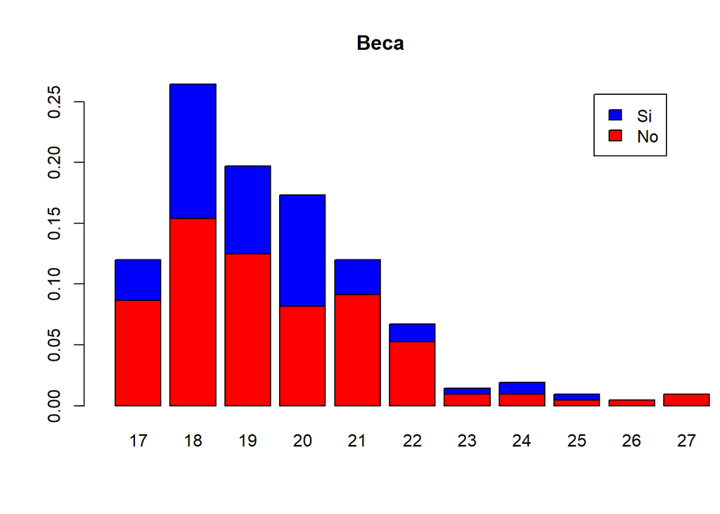

```r
barplot(prop.table(table(DF$Beca,DF$Edad)),col=c("red","blue"),legend.text=c("No","Si"),xlim=c(0,12), main="Beca")
```

##### **Ingresos**

Promedio: Lo que nos devuelve Rstudio en este apartado quiere decir que todos los datos dentro de la variable están alrededor de:

```r
mean(DF$Ingresos, na.rm = TRUE)
```

```
## [1] 659.8309
```

Rango: Nos dará una idea de la dispersión de los datos de la variable.

```r
max(DF$Ingresos, na.rm = TRUE) - min(DF$Ingresos, na.rm = TRUE)
```

```
## [1] 6000
```

Moda: En este caso es el valor de 0 pues se repite 31 veces. Aplicando histograma a esta variable nos damos cuenta que es unimodal.

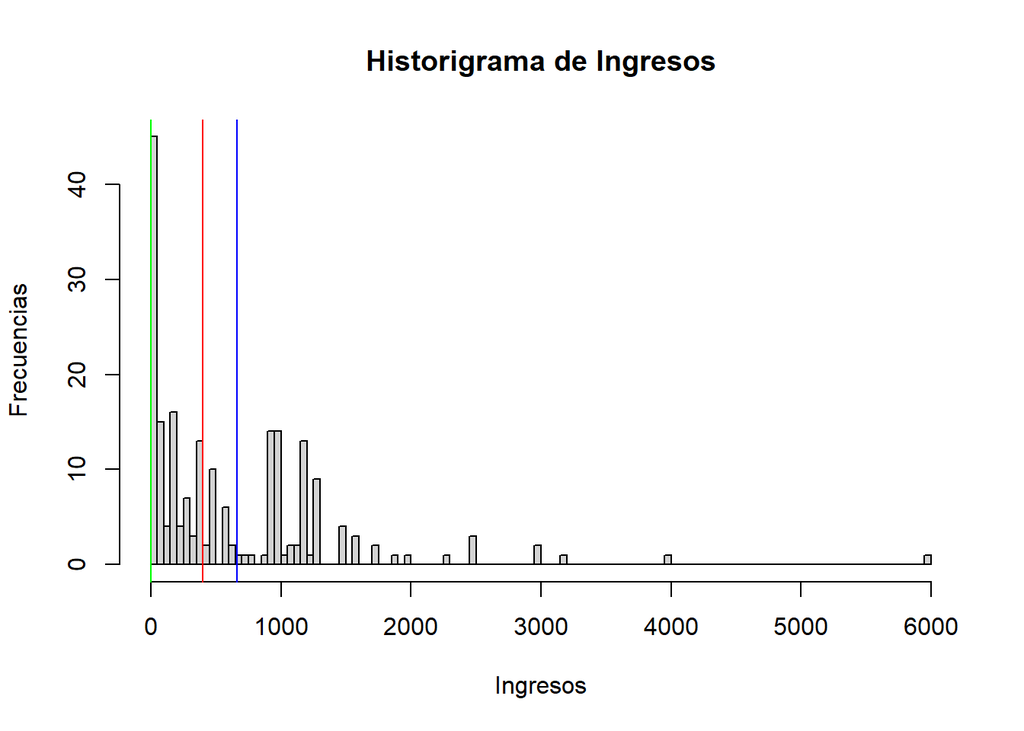

```r
hist(x = DF$Ingresos, xlab = "Ingresos", ylab = "Frecuencias", main = "Historigrama de Ingresos", 200)

abline(v=mean(DF$Ingresos, na.rm = TRUE), lwd=1, lty=1, col="blue")
abline(v=median(DF$Ingresos, na.rm = TRUE), lwd=1, lty=1, col="red")
abline(v=as.numeric(names(which.max(table(DF$Ingresos)))), lwd=1, lty=1, col="green")
```

Al aplicar histograma ayudándonos del gráfico de los descriptores numéricos hallados anteriormente podemos notar que la variable tiene un sesgo hacia la derecha.

##### CtoAlquiler

Promedio: Lo que nos devuelve Rstudio en este apartado quiere decir que todos los datos dentro de la variable están alrededor del promedio.

Máximo: El costo de alquiler máximo registrado es de:

```r
max(DF$CtoAlquiler, na.rm = TRUE)
```

```
## [1] 3200
```

Mínimo: Devuelve el mínimo valor de los datos registrados.

Mínimo tomando en cuenta el costo de alquiler mayor a 0.

```r
min(DF$CtoAlquiler[DF$CtoAlquiler > 0], na.rm = TRUE)
```

```
## [1] 100
```

Mínimo tomando en cuenta el costo de alquiler igual a 0.

```r
min(DF$CtoAlquiler, na.rm = TRUE)
```

```
## [1] 0
```

Se pueden concluir de estos descriptores que el máximo costo de alquiler que hemos conseguido ha sido 3200, lo que nos da una cierta idea de la capacidad económica de algunos estudiantes. Para tener una idea más clara de lo comentado anteriormente podemos aplicar una gráfica de densidad y ver si está más presente que se pague más o menos por alquiler.

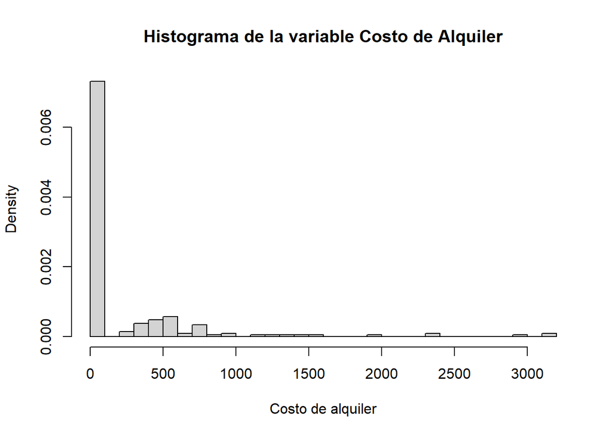

```r
hist(DF$CtoAlquiler, breaks = 30, freq = FALSE, main = "Histograma de la variable Costo de Alquiler", xlab = "Costo de alquiler")
```

Podemos ver que es más común que la gente pague entre 250 soles hasta 1000 soles por alquiler, sin embargo después de este intervalo no es común que la gente pague por alquiler.

Varianza: Nos da la variabilidad de los datos dentro de la variable. En este caso nos devuelve el dato en soles al cuadrado.

```r
var(DF$CtoAlquiler, na.rm = TRUE)
```

```
## [1] 283903.3
```

##### CtoTransporte

Promedio: El promedio de gasto diario en transporte público de la variable transporte es de:

```r
mean(DF$CtoTransporte[DF$TipoTransporte == "Transporte Público"], na.rm = TRUE)
```

```
## [1] 7.846538
```

Máximo: eL máximo valor dentro de la variable CtoTransporte es:

```r
max(DF$CtoTransporte, na.rm = TRUE)
```

```
## [1] 60
```

Varianza:

```r
var(DF$CtoTransporte[DF$TipoTransporte == "Transporte Público"], na.rm = TRUE)
```

```
## [1] 75.53458
```

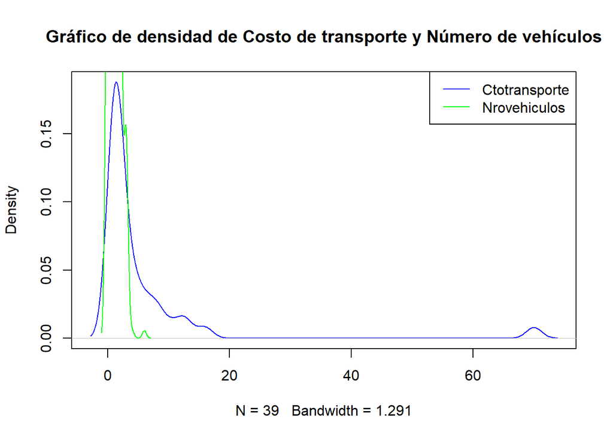

```r
plot(density(table(DF$CtoTransporte)),col="blue", main = "Gráfico de densidad de Costo de transporte y Número de vehículos")
lines(density(DF$CtdadVehiculos),col="green")
legend("topright", c("Ctotransporte", "Nrovehiculos"),
       lty = 1, col = c("blue", "green"))
```

##### Cantidad de vehículos

Minimo: El valor mínimo dentro de la variable CtdadVehiculos sin contar los 0 es:

```r
min(DF$CtdadVehiculos[DF$CtdadVehiculos > 0], na.rm = TRUE)
```

```
## [1] 1
```

Maximo: El valor maáximo de la variable CtdadVehiculos es:

```r
max(DF$CtdadVehiculos, na.rm = TRUE)
```

```
## [1] 6
```

Moda sin contar el 0: Aplicamos el comando table para ver cual valor se repite más en las variables

```r
table(DF$CtdadVehiculos[DF$CtdadVehiculos > 0])
```

```
##
##  1  2  3  4  6
## 47 64 27  1  1
```

#### Cantidad de Vehículos vs Costo de Transporte: Se observa una relación, mientras más vehículos se usan para ir a la universidad, más se gasta en transporte.

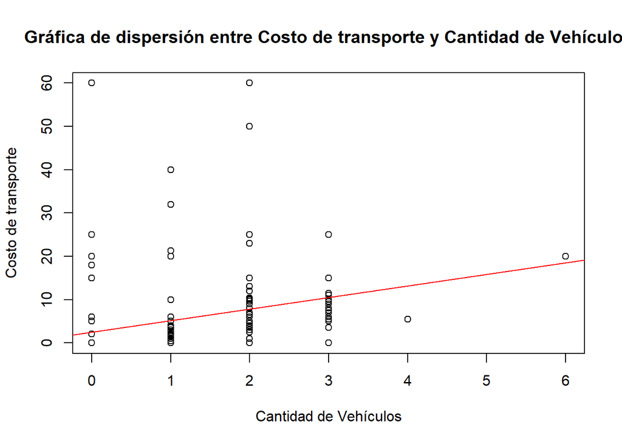

```r
plot(DF$CtdadVehiculos, DF$CtoTransporte, main = "Gráfica de dispersión entre Costo de transporte y Cantidad de Vehículos", xlab = "Cantidad de Vehículos", ylab = "Costo de transporte")
abline(lm(DF$CtoTransporte ~ DF$CtdadVehiculos  ), col= "red")
```

##### Covarianza y correlación:

```r
cor(x = DF$CtdadVehiculos, y = DF$CtoTransporte, use = "complete.obs")
```

```
## [1] 0.3314636
```

```r
cov(x = DF$CtdadVehiculos, y = DF$CtoTransporte, use = "complete.obs")
```

```
## [1] 3.319732
```

Al aplicar la covarianza y correlación obtenemos a un valor no demasiado cercano a 0 pero lejano a 1 por lo que existe una ligera asociación lineal. Asimismo, al aplicar la covarianza nos devuelve un valor positivo pero no tan grande, lo que quiere decir que la relación entre las variables es directa. Es decir, si existe una relación no muy fuerte entre las variables en donde si una crece la otra también lo hace.

##### CtdadCursos

Mínimo: El mínimo valor registrado en esta variable es:

```r
min(DF$CtdadCursos)
```

```
## [1] 1
```

Máximo: El valor máximo para la variable CtdadCursos es:

```r
max(DF$CtdadCursos)
```

```
## [1] 8
```

Moda: EL valor que más se repite en la variable CtdadCursos es 6.

```r
table(DF$CtdadCursos)
```

```
##
##  1  2  3  4  5  6  7  8
##  1  2  8 18 59 87 32  1
```

Rango: La variibilidad dada por el rango es de:

```r
max(DF$CtdadCursos) - min(DF$CtdadCursos)
```

```
## [1] 7
```

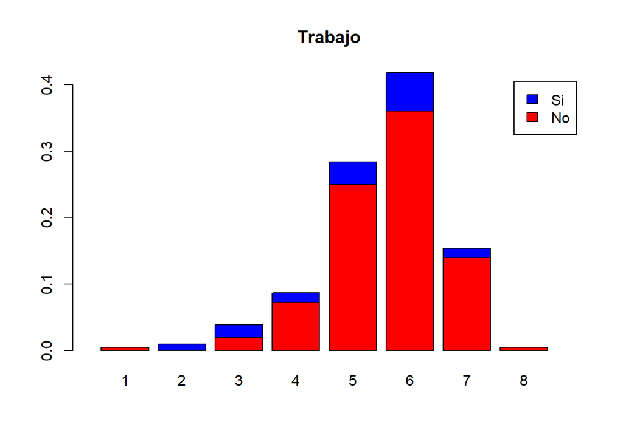

```r
barplot(prop.table(table(DF$Trabajo,DF$CtdadCursos)),col=c("red","blue"),legend.text=c("No","Si"),xlim=c(0,10), main="Trabajo")
```

##### HrasClase

Histograma

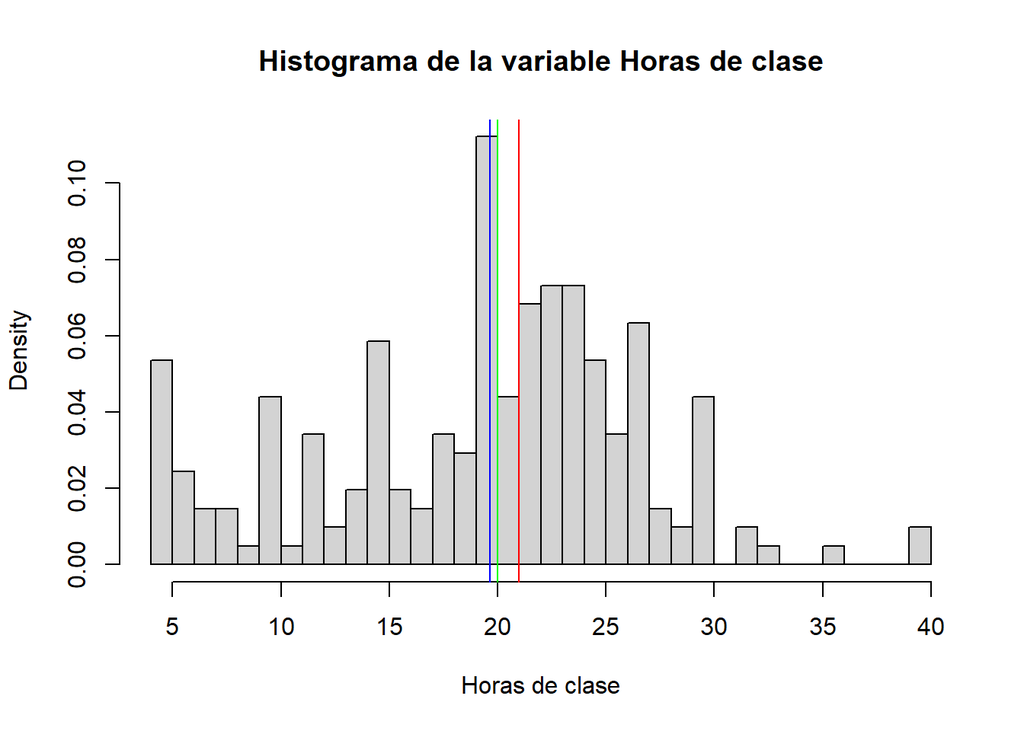

```r
hist(DF$HrasClase, breaks = 30, freq = FALSE, main = "Histograma de la variable Horas de clase", xlab = "Horas de clase")

abline(v=mean(DF$HrasClase, na.rm = TRUE), lwd=1, lty=1, col="blue")
abline(v=median(DF$HrasClase, na.rm = TRUE), lwd=1, lty=1, col="red")
abline(v=as.numeric(names(which.max(table(DF$HrasClase)))), lwd=1, lty=1, col="green")
```

Mínimo: El mínimo valor registrado dentro de variable HrasClase es:

```r
min(DF$HrasClase, na.rm = TRUE)
```

```
## [1] 4
```

Máximo: El máximo valor registrado dentro de la variable Hras de clase es de:

```r
max(DF$HrasClase, na.rm = TRUE)
```

```
## [1] 40
```

Mediana: La mediana en la variable HrasClase es:

```r
median(DF$HrasClase, na.rm = TRUE)
```

```
## [1] 21
```

Al aplicar los descriptores numéricos y añadiéndolos al gráfico podemos notar que nuestra variable es simétrica pues la media, la mediana y la moda son similares.

Varianza: La varianza en la variable HrasClase es:

```r
var(DF$HrasClase, na.rm = TRUE)
```

```
## [1] 54.62793
```

```r
sd(DF$HrasClase, na.rm = TRUE)
```

```
## [1] 7.391071
```

Estos descriptores nos dan un sentido de cómo varían los datos de nuestra variable, es decir, si ordenamos por ejemplo en un gráfico de manera ordenada a nuestra variable Horas de clase podemos ver lugares en donde hay más separación entre los resultados, lo que podría indicar que hay mayor varianza en aquel lugar.

##### **HrasEstudio**

[figure not shown]

```r
hist(DF$HrasEstudio, breaks = 30, freq = FALSE, main = "Histograma de la variable Horas de clase", xlab = "Horas de clase")

abline(v=mean(DF$HrasEstudio, na.rm = TRUE), lwd=1, lty=1, col="blue")
abline(v=median(DF$HrasEstudio, na.rm = TRUE), lwd=1, lty=1, col="red")
abline(v=as.numeric(names(which.max(table(DF$HrasEstudio)))), lwd=1, lty=1, col="green")
```

**Promedio**: El promedio de la variable HrasEstudio es:

```r
mean(DF$HrasEstudio, na.rm = TRUE)
```

```
## [1] 11.48725
```

**Minimo**: El mínimo valor registrado dentro de la variable HrasEstudio es:

```r
min(DF$HrasEstudio, na.rm = TRUE)
```

```
## [1] 1
```

Máximo: El máximo valor registrado dentro de la variable HrasEstudio es:

```r
max(DF$HrasEstudio, na.rm = TRUE)
```

```
## [1] 45
```

Aplicando el histograma y con ayuda de los descriptores numéricos vemos que la variable es asimétrica y tiene un sesgo a la derecha.

Varianza: La varianza en la variable HrasEstudio es de:

```r
var(DF$HrasEstudio, na.rm = TRUE)
```

```
## [1] 76.92378
```

#### Horas de clase vs Horas de Estudio

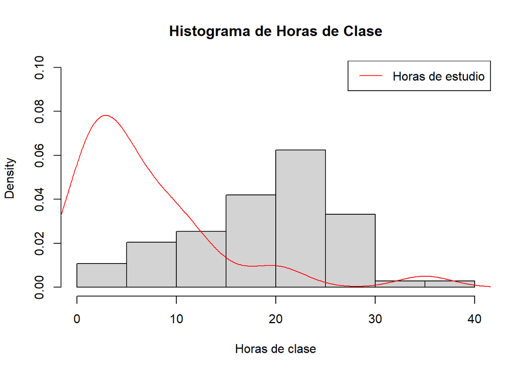

```r
hist(DF$HrasClase,ylim=c(0,0.099),freq = F,breaks = "FD", xlab = "Horas de clase", main = "Histograma de Horas de Clase")
lines(density(table(DF$HrasEstudio)),col="red",lty=1)
legend("topright", c("Horas de estudio"),
       lty = 1,col=c("red"))
```

#### Variables Categóricas

BECA -DESCRIPCIÓN DE LA VARIABLE: Esta variable es importante puesto que, nos ayudara a relacionar a los alumnos que tienen becas con las variables(numericas o categoricas) y saber si esta esta relacionada con el nivel economico de los alumnos

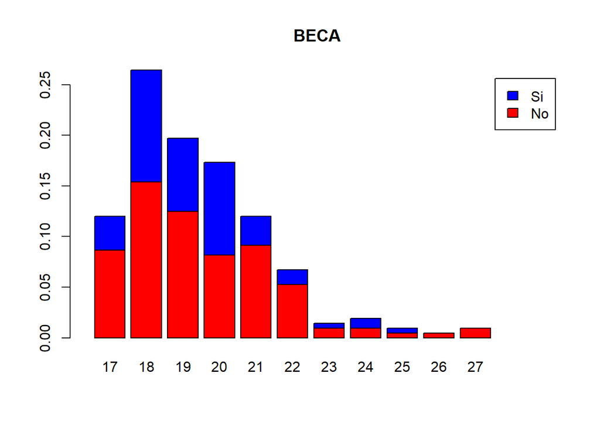

```r
barplot(prop.table(table(DF$Beca,DF$Edad)),col=c("red","blue"),
      legend.text=c("No","Si"),xlim=c(0,15), main="BECA")
```

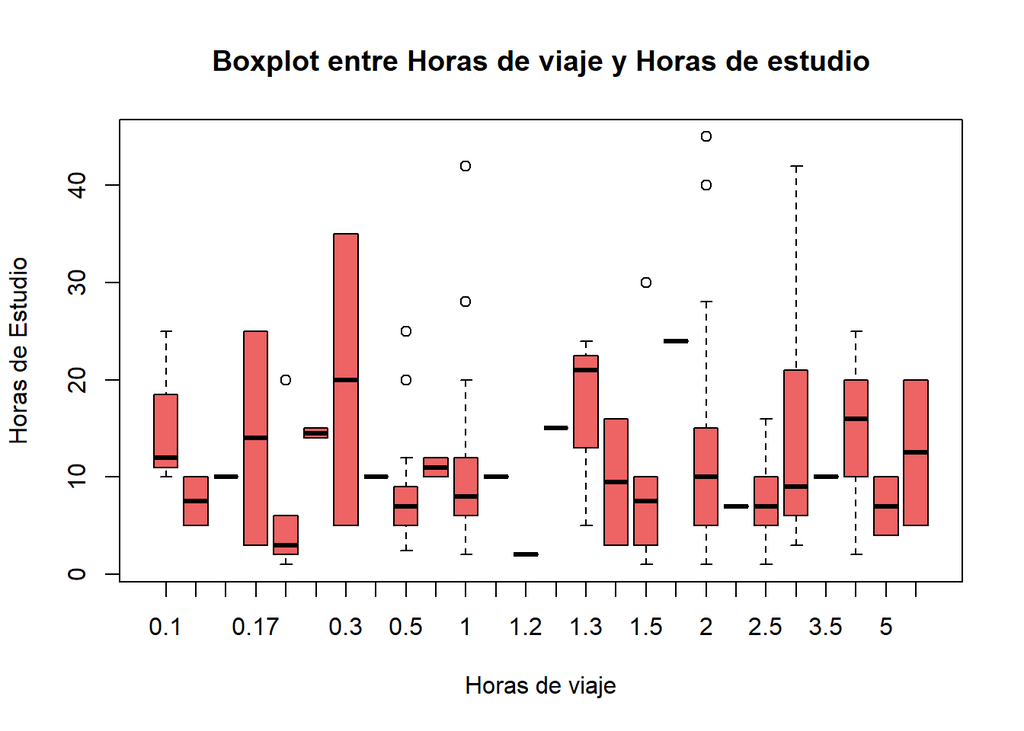

```r
boxplot(DF$HrasEstudio~DF$HrsViaje, main = "Boxplot entre Horas de viaje y Horas de estudio", ylab = "Horas de Estudio", xlab = "Horas de viaje", col = "indianred2")
```

TRABAJO Esta variable nos ayudara a conocer si los alumnos de la utec se encuentran trabajando y a la vez estudiando,por lo cual podriamos relacionarlo con su nivel socieconomico o si es becado.

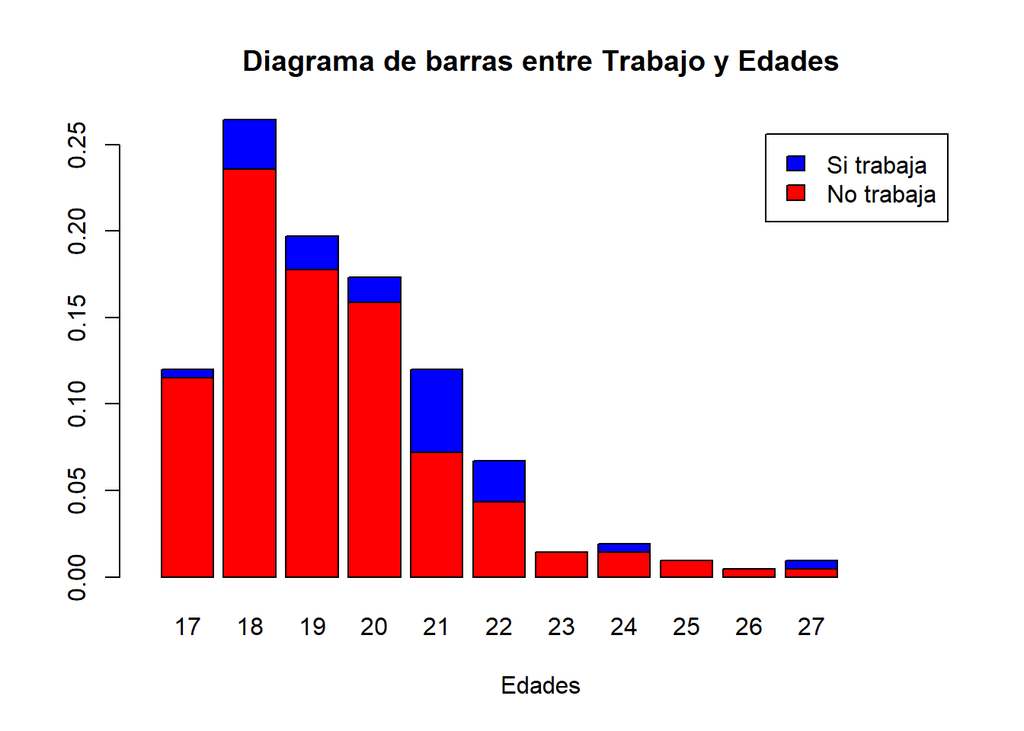

```r
barplot(prop.table(table(DF$Trabajo,DF$Edad)),col=c("red","blue"),
      legend.text=c("No trabaja","Si trabaja"),xlim=c(0,15), main="Diagrama de barras entre Trabajo y Edades", xlab = "Edades")
```

Beca vs Trabajo

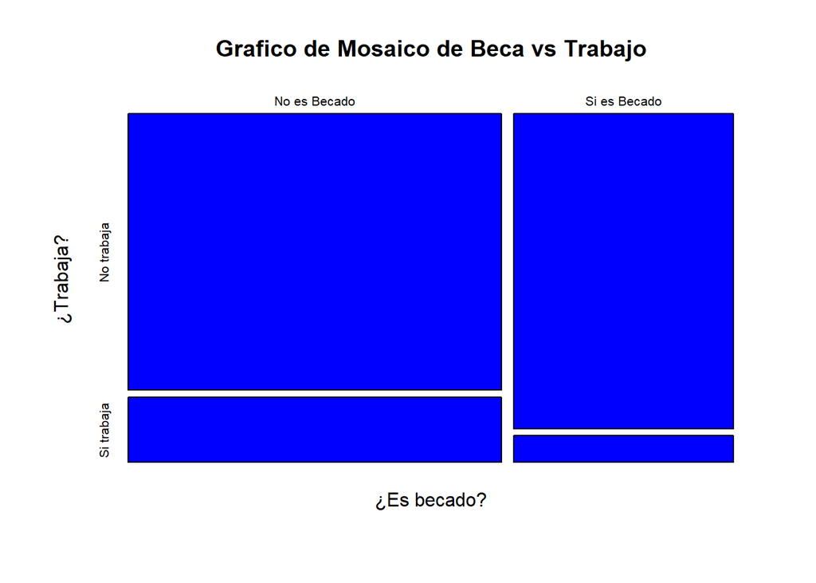

```r
Bequita <- DF$Beca
Bequita[Bequita == "Si"] <- "Si es Becado"
Bequita[Bequita == "No"] <- "No es Becado"
Trabajito <- DF$Trabajo
Trabajito[Trabajito == "Si"] <- "Si trabaja"
Trabajito[Trabajito == "No"] <- "No trabaja"

mosaicplot(table(Bequita, Trabajito),col = "blue",main="Grafico de Mosaico de Beca vs Trabajo", xlab = "¿Es becado?", ylab = "¿Trabaja?")
```

ALQUILER esta variable dara conocer si los alumnos viven en casa propia o alquilan. Por otro lado, esta variable esta relacionada con otras variables ya sean numericas o categoricas y nos ayudara a saber la situacion del alumno.

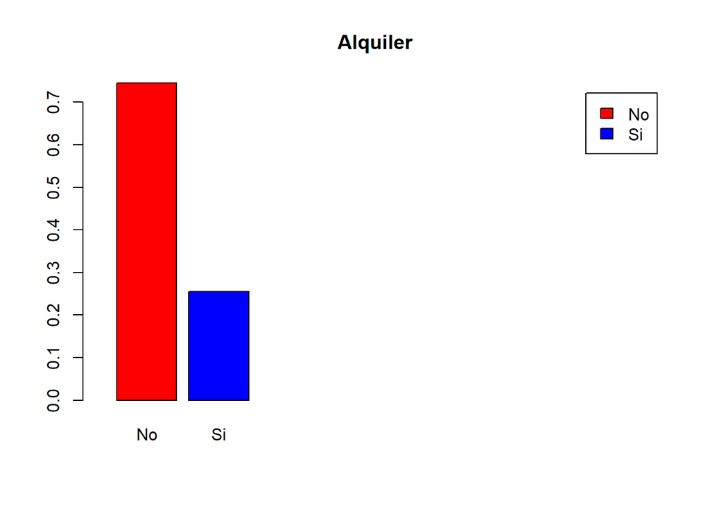

```r
barplot(prop.table(table(DF$Alquiler)),col=c("red","blue"),
      legend.text=c("No","Si"),xlim=c(0,9), main="Alquiler")
```

Alquiler vs trabajo

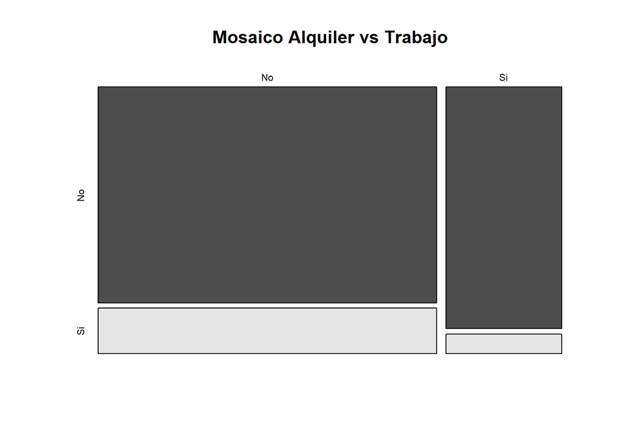

```r
AT<-table(DF$Alquiler,DF$Trabajo)
mosaicplot(AT,color = TRUE,main="Mosaico Alquiler vs Trabajo")
```

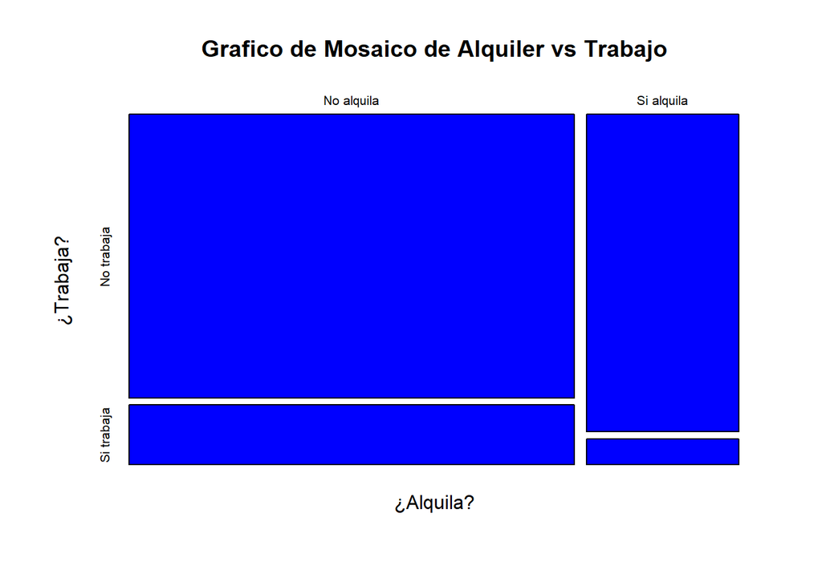

```r
Alquilito <- DF$Alquiler
Alquilito[Alquilito == "Si"] <- "Si alquila"
Alquilito[Alquilito == "No"] <- "No alquila"
Trabajito <- DF$Trabajo
Trabajito[Trabajito == "Si"] <- "Si trabaja"
Trabajito[Trabajito == "No"] <- "No trabaja"

mosaicplot(table(Alquilito, Trabajito),col = "blue",main="Grafico de Mosaico de Alquiler vs Trabajo", xlab = "¿Alquila?", ylab = "¿Trabaja?")
```

Tipo de Transporte

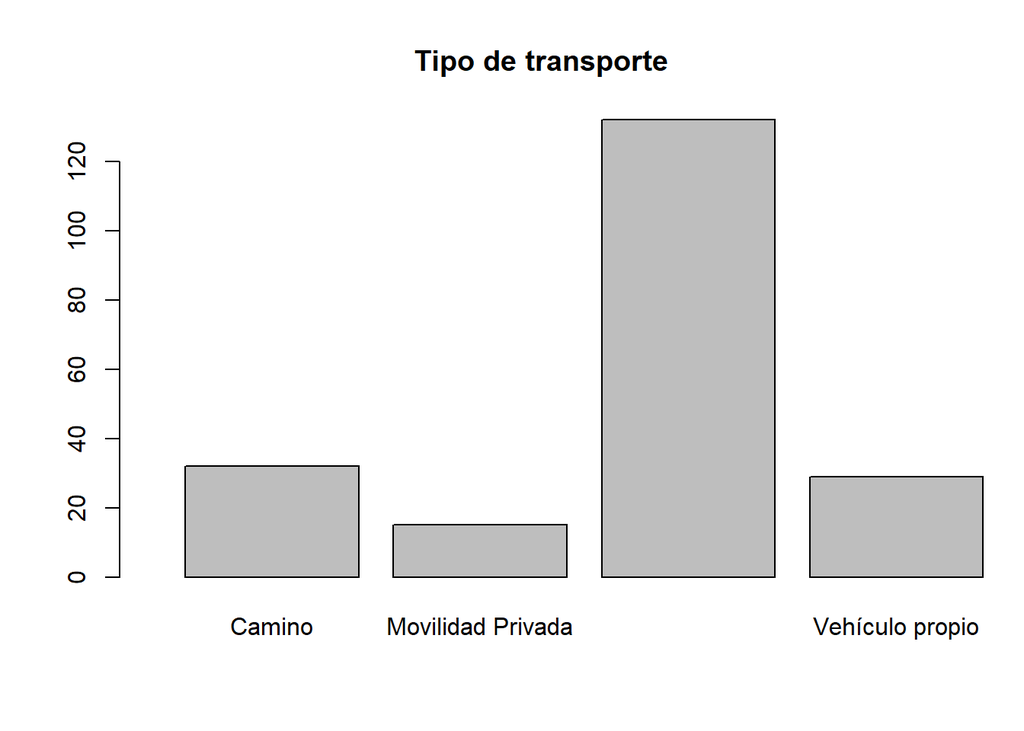

```r
barplot(table(DF$TipoTransporte),main = "Tipo de transporte", xlim=c(0, 4.5))
```

Comodidad:

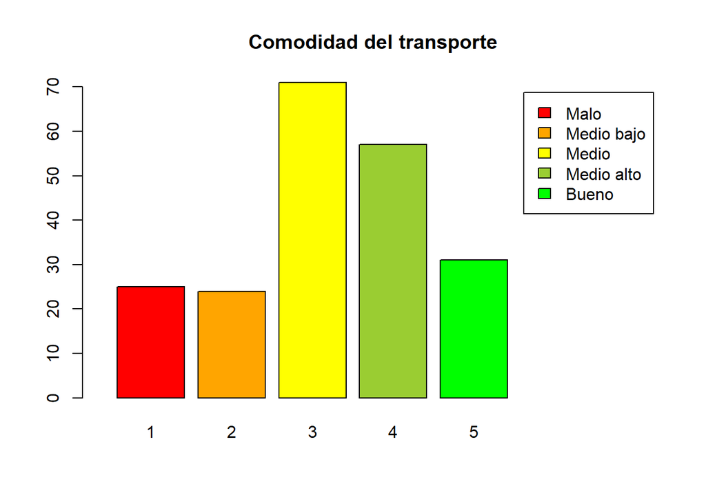

```r
barplot(table(DF$Comodidad), col=c("red", "orange", "yellow","yellowgreen","green"),main = "Comodidad del transporte", xlim = c(0,8),legend.text=c("Malo","Medio bajo","Medio","Medio alto","Bueno"))
```

Tipo de transporte vs comodidad Podemos observar que la mayoria de los alumnos usa transporte publico

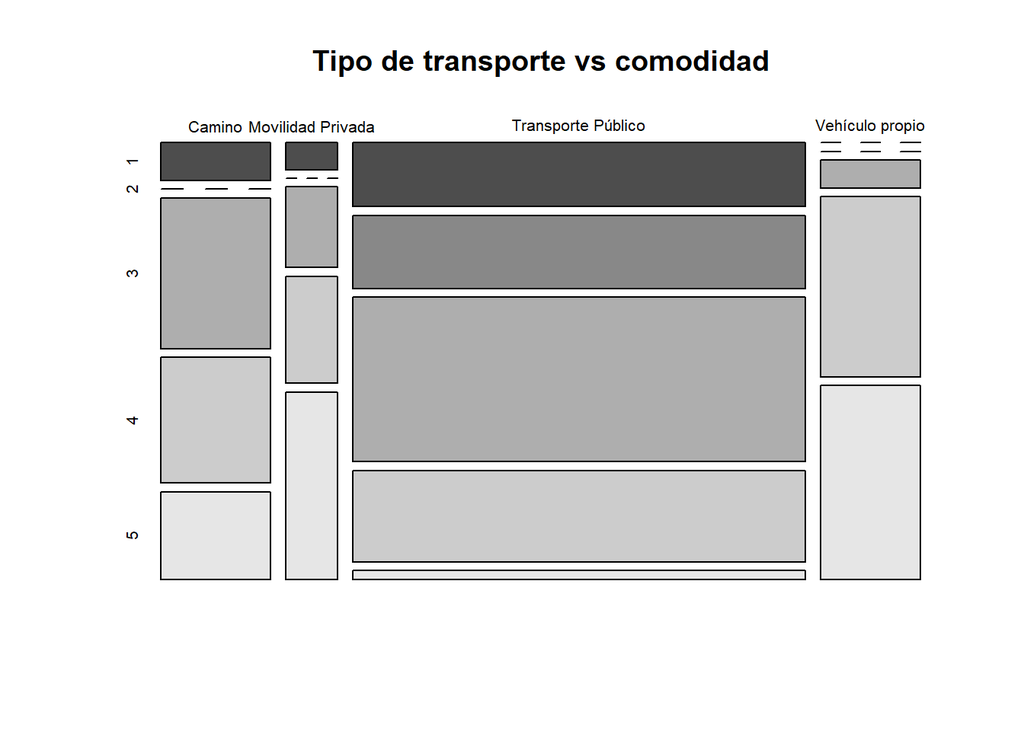

```r
TC<-table(DF$TipoTransporte,DF$Comodidad)
mosaicplot(TC,color = TRUE,main = "Tipo de transporte vs comodidad")
```

Calidad de Enseñanza:

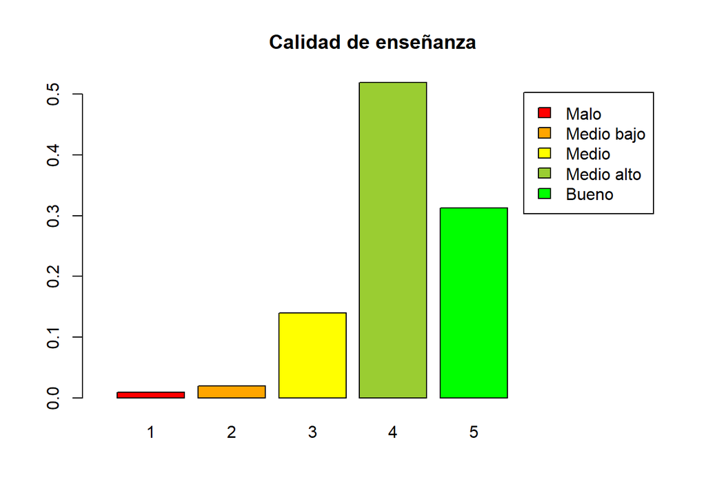

```r
barplot(prop.table(table(DF$Calidad)), col=c("red", "orange", "yellow","yellowgreen","green"),main = "Calidad de enseñanza", xlim = c(0,8),legend.text=c("Malo","Medio bajo","Medio","Medio alto","Bueno"))
```

Estres: Esta variable nos dará información del grado de estrés que presentan los estudiantes de UTEC en este presente ciclo, este nivel de estrés estaría determinado por el número de cursos en los cuales estan inscritos.

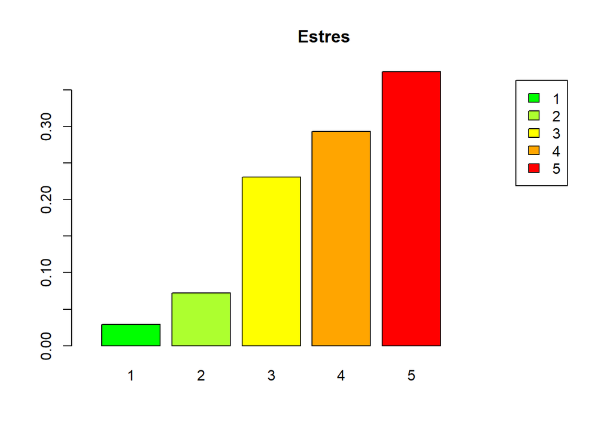

```r
barplot(prop.table(table(DF$Estres)),col=c("green","greenyellow","yellow","orange","red"),
        legend.text=c("1","2","3","4","5"),xlim=c(0,8), main="Estres")
```

### Patrones

Para encontrar relaciones entre dos variables utilizamos gráficos de densidad, barras y dispersión. Los patrones que logramos apreciar fueron entre la cantidad de vehículos y el costo de transporte, la cantidad de personas y la cantidad de ingreso y las horas de estudio y la de clases. En el caso de la cantidad de vehículos pudimos observar que las dos variables aumentan, a mayor cantidad de vehículos hay mayor costo de transporte; también que a menos números de personas que habiten juntos será mayor el ingreso que se obtenga; y que a menor horas de clases hay más horas de estudio. También utilizamos medidas de dispersión de datos para averiguar la ubicación de nuestros datos, por ejemplo usamos la moda y promedio para lograr ubicar la posición de nuestros datos sin necesidad de visualizar una gráfica.

# Análisis probabilístico

## Reconocimiento de modelos y Análisis

### Reconocimiento de un modelo Poisson en la variable Número de Personas

Comenzamos graficando un histograma para ver la distribución de esta variable

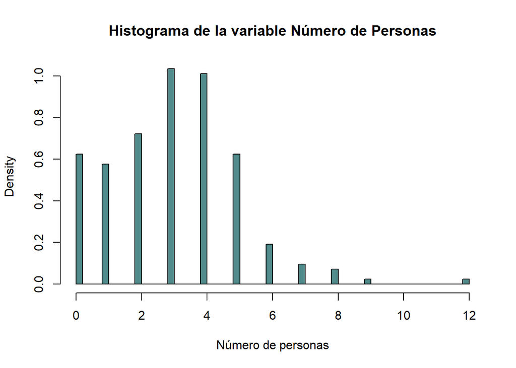

```r
hist(DF$NroPersonas, breaks = 50, freq = FALSE, main = "Histograma de la variable Número de Personas", xlab = "Número de personas", col = "darkslategray4")
```

A simple vista podemos afirmar que se trata de un poisson por lo que confirmaremos nuestras sospechas tomando en cuenta que la media y la varianza del modelo Poisson son iguales

```r
mean(DF$NroPersonas, na.rm = TRUE)
```

```
## [1] 3.038462
```

```r
var(DF$NroPersonas, na.rm = TRUE)
```

```
## [1] 4.027499
```

$$X \sim Poisson(\lambda)$$

$$E(X)=\lambda$$
$$Var(X)=\lambda$$

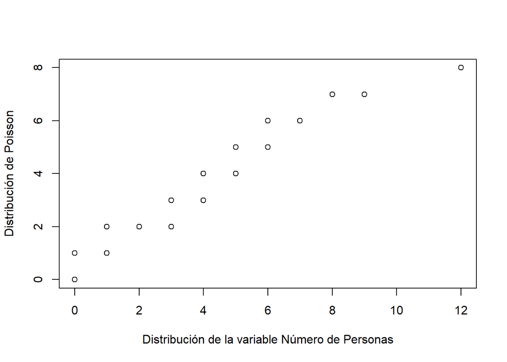

```r
qqplot(DF$NroPersonas, rpois(length(DF$NroPersonas), lambda = mean(DF$NroPersonas)), ylab = "Distribución de Poisson", xlab = "Distribución de la variable Número de Personas")
```

Vemos que hay una relación bastante directa por lo que con esto confirmamos nuestras sospechas de que la variable Número de Personas en efecto sigue una distribución del modelo Poisson.

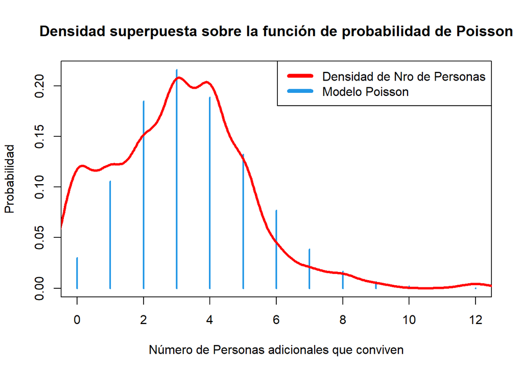

```r
plot(0:12, dpois(0:12, 3.5), type = "h",col = "68", lwd = 2,ylab = "Probabilidad", xlab = "Número de Personas adicionales que conviven", main = "Densidad superpuesta sobre la función de probabilidad de Poisson")

legend("topright",c("Densidad de Nro de Personas","Modelo Poisson"),col=c("red","68"),lty=1:1,lwd = 5)

lines(density(DF$NroPersonas, na.rm = TRUE), col = "red", lwd = 3)
```

Calculando probabilidades

En este apartado el objetivo es crear ejercicios dentro de nuestras variables aplicando los modelos de distribución que siguen para luego comparar la probabilidad que resulta de aplicar la función del modelo Poisson con la de la variable Número de Personas con el objetivo de comprobar nuevamente que esta variable sigue el comportamiento de un modelo Poisson.

Ejercicio 1: Calcular la probabilidad de que Una persona encuestada viva con cuatro personas. Ejercicio 2: Calcular la probabilidad de que una persona encuestada viva con 5 personas.

```r
#Ejercicio 1
dpois(4, 3.5)
```

```
## [1] 0.1888123
```

```r
#Ejercicio 2
dpois(5, 3.5)
```

```
## [1] 0.1321686
```

Ahora compararemos este resultado con la probabilidad de que me salga 4 siendo el espacio muestral nuesta variable Número de Personas.

```r
table(DF$NroPersonas)
```

```
##
##  0  1  2  3  4  5  6  7  8  9 12
## 26 24 30 43 42 26  8  4  3  1  1
```

```r
#Ejercicio 1
42/208
```

```
## [1] 0.2019231
```

```r
#Ejercicio 2
26/208
```

```
## [1] 0.125
```

Podemos notar que los resultados si bien es cierto no son iguales son parecidos por lo que concluimos que en efecto esta variable Número de personas sigue un modelo Poisson.

### Sospecha de un modelo Exponencial y reconocimiento de el modelo Gamma en la variable Costo de transporte

Al graficar el histograma de la variable costo de transporte obtenemos lo siguiente:

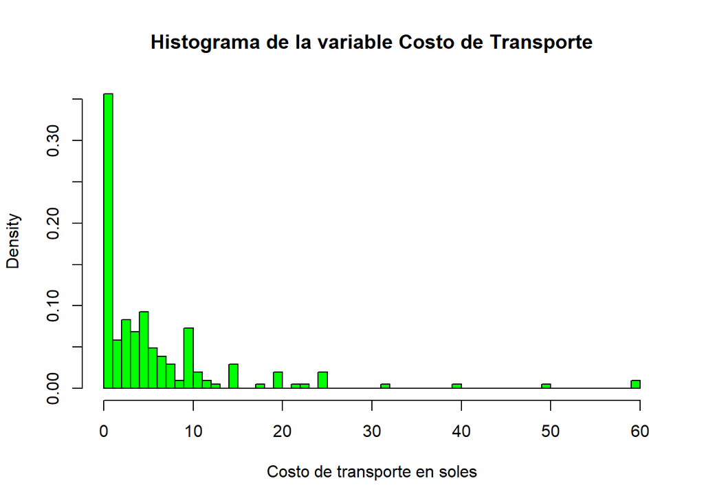

```r
hist(DF$CtoTransporte, breaks = 50, freq = FALSE, main = "Histograma de la variable Costo de Transporte", xlab = "Costo de transporte en soles", col = "green")
```

Pudimos observar que la variable Costo de transporte seguía el comportamiento de una variable aleatoria continua, con un modelo muy parecido al de una exponencial, por lo tanto primero nombraremos a nuestra variable aleatoria como X.
$$X \sim
Exponencial(λ)$$
La media de una variable aleatoria exponencial es igual a 1/λ, y necesitamos el valor de λ por lo que lo hallaremos despejando la ecuación y descartando los na del estudio.

```r
lambda<-1/mean(DF$CtoTransporte, na.rm=T)
```

Ahora que tenemos el valor de lambda podemos graficar nuestra función exponencial junto con el histograma de costo de transporte.

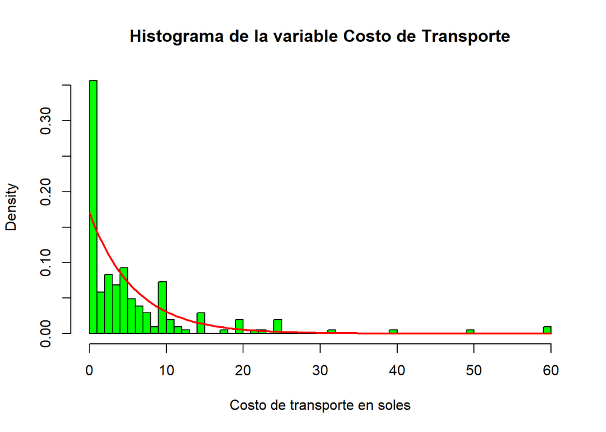

```r
hist(DF$CtoTransporte, breaks = 50, freq = FALSE, main = "Histograma de la variable Costo de Transporte", xlab = "Costo de transporte en soles", col = "green")
curve(dexp(x, lambda), lwd=2, col="red", add = T)
```

A simple vista se observa que la gráfica es muy parecida, pero necesitamos confirmar que se cumplen los propiedades de una distribución exponencial. Los valores de varianza y media son:

```r
var(DF$CtoTransporte, na.rm=T)
```

```
## [1] 80.97578
```

```r
mean(DF$CtoTransporte, na.rm=T)
```

```
## [1] 5.870976
```

La varianza debe cumplir:
$$Var=
\frac{1}{λ^2}$$
Remplazando nuestro valor de lambda nos da un valor de 34.46835 y el valor real de varianza es de 80.97578, la diferencia es mucha por eso no podemos afirmar que la variable siga una distribución exponencial. Probaremos con otro modelo de distribucion como el Gamma.
$$X \sim Gamma(α,λ)$$
Para hallar los valores de α y λ realizaremos un sistema de ecuaciones con los datos que obtenemos de R, sabemos que la varianza tiene valor de 80.97578 y la media tiene valor de 5.870976. Remplazaremos en el siguiente sistema de ecuaciones:
$$E(X)=\frac{α}{λ}\\ Var(X)=\frac{α}{λ^2}$$
Obtenemos los valores de α y λ, siendo 0.4256626 y 0.0725028 respectivamente. La grafica se muestra a continuación:

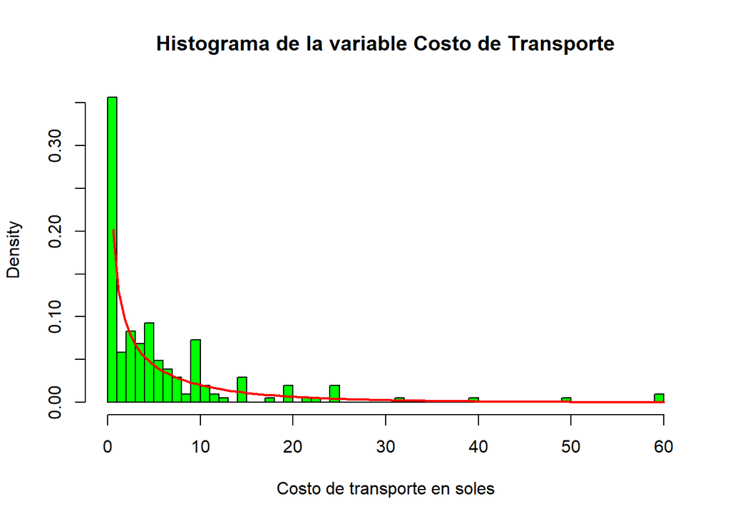

```r
alfa<-134642028096/316311640625
lambda<- 1467744/20243945
hist(DF$CtoTransporte, breaks = 50, freq = FALSE, main = "Histograma de la variable Costo de Transporte", xlab = "Costo de transporte en soles", col = "green")
curve(dgamma(x, alfa, lambda), lwd=2, col="red", add = T)
```

Ahora despues de obtener los valores de alfa, lambda y observar graficamnete podemos afirmar que la variable cumple con el comportamiento de una variable aleatoria gamma. Ahora veremos unos cuantos ejercicios: ¿Cuál es la probabilidad de que un estudiante de UTEC pague 10 soles a más de pasaje?

```r
pgamma(10, alfa, lambda, lower.tail=F)
```

```
## [1] 0.1903266
```

La probabilidad de que un estudiante de UTEC pague 10 soles a más es de un 19.03%, el valor real es de 20.19%. El valor real es el numero de casos favorables que tenemos en nuestra muestra entre el numero de nuestro universo.

¿Cuál es la probabilidad de que un estudiante de UTEC no gaste en pasaje más de 5 soles en pasaje?

```r
pgamma(5, alfa, lambda)
```

```
## [1] 0.6611396
```

La probabilidad de que un estudiante de UTEC no gaste más de 5 soles en pasaje es de 66.11% según nuestro modelo. La probabilidad real es de 64.90%. Nuestra aproximación es buena y no esta muy alejada del valor real.

Podemos concluir que nuestra variable si cumple con el comportamiento de una distribución gamma y podemos usar esta para aproximar buenos valores de probabilidad. Además si fuéramos a recolectar más encuestas observaríamos como nuestra variable de Costo de transporte se va asemejando cada vez más a una distribución gamma.

### Reconocimiento del modelo Gamma en la variabble Horas de Estudio

Al graficar el histograma de la variable horas de estudio tenemos lo siguiente

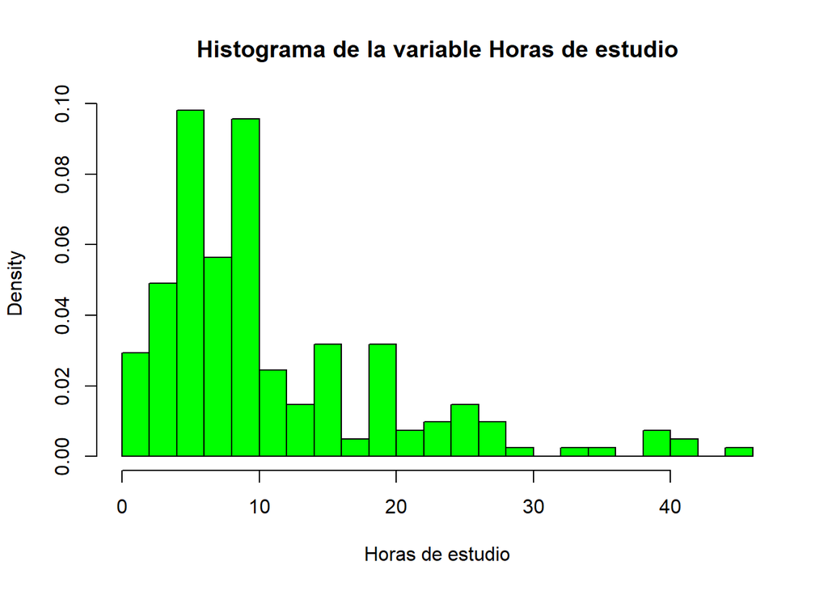

```r
hist(DF$HrasEstudio, breaks = 30, freq = FALSE, main = "Histograma de la variable Horas de estudio", xlab = "Horas de estudio", col = "green")
```

A simple vista podemos ver que podria ser una distribuicion normal, para eso necesitaremos realizar un test

```r
t.test(DF$HrasEstudio)
```

```
##
##  One Sample t-test
##
## data:  DF$HrasEstudio
## t = 18.707, df = 203, p-value < 2.2e-16
## alternative hypothesis: true mean is not equal to 0
## 95 percent confidence interval:
##  10.27649 12.69802
## sample estimates:
## mean of x
##  11.48725
```

```r
shapiro.test(DF$HrasEstudio)
```

```
##
##  Shapiro-Wilk normality test
##
## data:  DF$HrasEstudio
## W = 0.84418, p-value = 1.599e-13
```

```r
table(DF$HrasEstudio)
```

```
##
##   1   2 2.4   3   4   5   6   7   8   9  10  12  14  15  16  18  20  21  22  24
##   5   7   1   9  10  19  21  10  13   4  35  10   6   5   8   2  13   2   1   4
##  25  26  28  30  34  35  40  42  45
##   5   1   4   1   1   1   3   2   1
```

```r
var(DF$HrasEstudio,na.rm = T)
```

```
## [1] 76.92378
```

```r
mean(DF$HrasEstudio,na.rm = T)
```

```
## [1] 11.48725
```

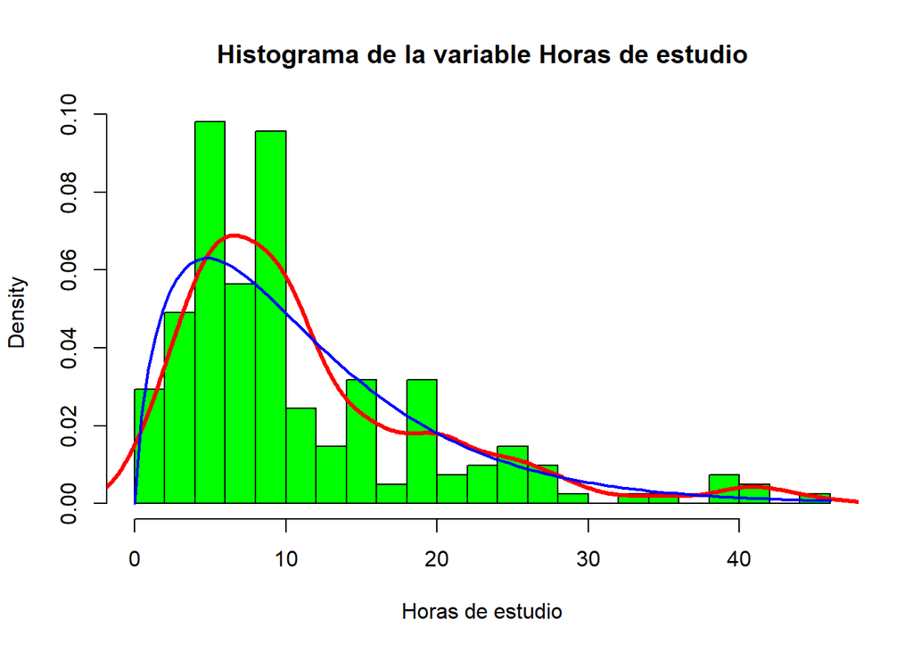

```r
hist(DF$HrasEstudio, breaks = 30, freq = FALSE, main = "Histograma de la variable Horas de estudio", xlab = "Horas de estudio", col = "green")
lines(density(DF$HrasEstudio, na.rm = TRUE), col = "red", lwd = 3)


curve(dgamma(x,11.48725*11.48725/76.92378,11.48725/76.92378),lwd = 2, col="blue", add = T)
```

```r
mu <- mean(DF$HrasEstudio, na.rm=T)
var(DF$HrasEstudio, na.rm=T)
```

```
## [1] 76.92378
```

```r
ks.test(DF$HrasEstudio, "pnorm", mu, sd(DF$HrasEstudio,na.rm=T))
```

```
##
##  One-sample Kolmogorov-Smirnov test
##
## data:  DF$HrasEstudio
## D = 0.22419, p-value = 2.484e-09
## alternative hypothesis: two-sided
```

```r
sigma <- sd(DF$HrasEstudio, na.rm=T)
```

Ahora después de obtener los valores de alfa, lambda y observar gráficamente podemos afirmar que la variable cumple con el comportamiento de una variable aleatoria gamma. Ahora veremos unos cuantos ejercicios: 1. ¿Cuál es la probabilidad de que un estudiante de UTEC estudie más de 15 horas?

```r
alf<-11.48725*11.48725/76.92378
lamb<-11.48725/76.92378
pgamma(15, alf, lamb, lower.tail=F)
```

```
## [1] 0.2685441
```

```r
sum(table(DF$HrasEstudio[DF$HrasEstudio<10]))
```

```
## [1] 99
```

¿Cuál es la probabilidad de que un estudiante de UTEC no estudie mas de 9 horas?

```r
pgamma(9,alf,lamb)
```

```
## [1] 0.4818302
```

La probabilidad de que un estudiante de UTEC no estudie más de 9 horas según nuestro modelo es de 48.18%. La probabilidad real es de 47.59. Nuestra aproximación es buena y no esta muy alejada del valor real.

Con esta gráfica podemos observar cual es la probabilidad de que un estudiante estudie de 0 a 20 horas

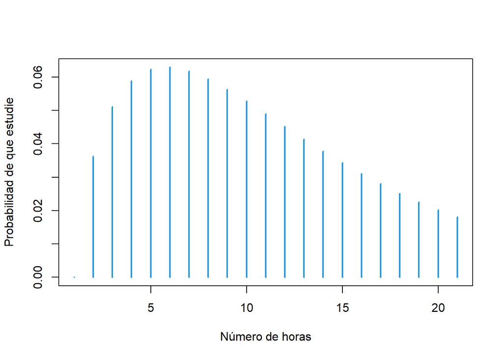

```r
plot(dgamma(0:20,alf,lamb ), type = "h",col = "68", lwd = 2,ylab = "Probabilidad de que estudie", xlab = "Número de horas")
```

Podemos concluir que nuestra variable si cumple con el comportamiento de una distribución gamma, también podemos observar que la probabilidad de que un estudiante estudie mas horas que la media va disminuyendo, podemos usar esta para aproximar buenos valores de probabilidad. Además si fuéramos a recolectar más encuestas observaríamos como nuestra variable Horas de estudio se va asemejando cada vez más a una distribución gamma.